# Informe intermig

JHJ

20/12/2024

## Pre-Processament de les dades

```r
simulacions = mutate(simulacions[c(1,2)], simulacions[c(3,4,5,6,7,8)]*60)
```

## Qüestió principal

La qüestió principal que estem estudiant és, quina és la forma dels errors? És a dir, si els errors segueixen una forma lineal, logarítmica, exponencial, etc…?

La qüestió principal porta a preguntar-nos, com podem modelar la v.a. `temps d'execució` d’un algoritme?

## Conjunt de dades

En el nostre conjunt de dades hi tenim dues taules. Una on tenim la informació de cada algoritme que hem implementat fent servir el llenguatge C++, *executant el codi des de R*. I una altra on tenim la informació de cada simulació que hem fet amb cada algoritme fent servir vectors de mides diferents, ordenats i desordenats.

Les simulacions les vam generar seguint els passos que vam aprendre al qüestionari de *com executar codi c++ des de R* del moodle, i fent servir algunes funcions de la llibreria `tidyverse` i `dplyr` de R, també vam implementar algunes funcions d’R que generaven les simulacions.

Per saber quines variables hi ha, i quantes observacions s’han generat podem fer servir la funció `glimpse()` amb el conjunt de dades `algoritmes`. Aquesta taula conté informació de cada algoritme **dels que hem implementat**, i que conté variables independents com: el nom de l’algoritme, si l’algoritme és estable o no (entenent estabilitat com que l’algoritme manté el temps d’execució sense moltes variacions independentment de la mida del vector, ordenat i desordenat), i si l’algoritme té una implementació recursiva o no. En conclusió, aquest conjunt té l’estructura següent:

```r
glimpse(algoritmes)
```

```
## Rows: 3
## Columns: 3
## $ algoritme               <chr> "bubblesort", "quicksort", "mergesort"
## $ estable                 <lgl> TRUE, FALSE, TRUE
## $ implementacio.recursiva <lgl> FALSE, TRUE, TRUE
```

```r
glimpse(simulacions)
```

```
## Rows: 5,000
## Columns: 8
## $ experiment     <int> 1, 1, 1, 1, 1, 1, 1, 1, 1, 1, 1, 1, 1, 1, 1, 1, 1, 1, 1…
## $ mida           <dbl> 10, 20, 30, 40, 50, 60, 70, 80, 90, 100, 110, 120, 130,…
## $ bubblesort     <dbl> 0.000048, 0.000150, 0.000348, 0.000606, 0.000924, 0.001…
## $ quicksort      <dbl> 0.000018, 0.000024, 0.000048, 0.000066, 0.000072, 0.000…
## $ mergesort      <dbl> 0.000078, 0.000132, 0.000210, 0.000222, 0.000288, 0.000…
## $ ord.bubblesort <dbl> 0.000030, 0.000102, 0.000216, 0.000366, 0.000564, 0.000…
## $ ord.quicksort  <dbl> 0.000012, 0.000018, 0.000036, 0.000054, 0.000072, 0.000…
## $ ord.mergesort  <dbl> 0.000096, 0.000114, 0.000210, 0.000210, 0.000270, 0.000…
```

A partir d’aquí vam fer una descriptiva del conjunt `simulacions` fent servir la funció `summary()` com.

```r
summary(simulacions)
```

```
##    experiment        mida          bubblesort         quicksort
##  Min.   : 1.0   Min.   :  10.0   Min.   :0.000042   Min.   :0.000006
##  1st Qu.:13.0   1st Qu.: 257.5   1st Qu.:0.024014   1st Qu.:0.000480
##  Median :25.5   Median : 505.0   Median :0.094047   Median :0.001050
##  Mean   :25.5   Mean   : 505.0   Mean   :0.124893   Mean   :0.001095
##  3rd Qu.:38.0   3rd Qu.: 752.5   3rd Qu.:0.210026   3rd Qu.:0.001662
##  Max.   :50.0   Max.   :1000.0   Max.   :0.506994   Max.   :0.007356
##    mergesort        ord.bubblesort     ord.quicksort      ord.mergesort
##  Min.   :0.000048   Min.   :0.000024   Min.   :0.000006   Min.   :0.000048
##  1st Qu.:0.001488   1st Qu.:0.013912   1st Qu.:0.001452   1st Qu.:0.001133
##  Median :0.003132   Median :0.053091   Median :0.005496   Median :0.002193
##  Mean   :0.003217   Mean   :0.070568   Mean   :0.007261   Mean   :0.002251
##  3rd Qu.:0.004866   3rd Qu.:0.118045   3rd Qu.:0.012198   3rd Qu.:0.003378
##  Max.   :0.014742   Max.   :0.299082   Max.   :0.059976   Max.   :0.011586
```

I també vam poder visualitzar les simulacions amb la funció `ggplot()`.

### BubbleSort *desordenat*

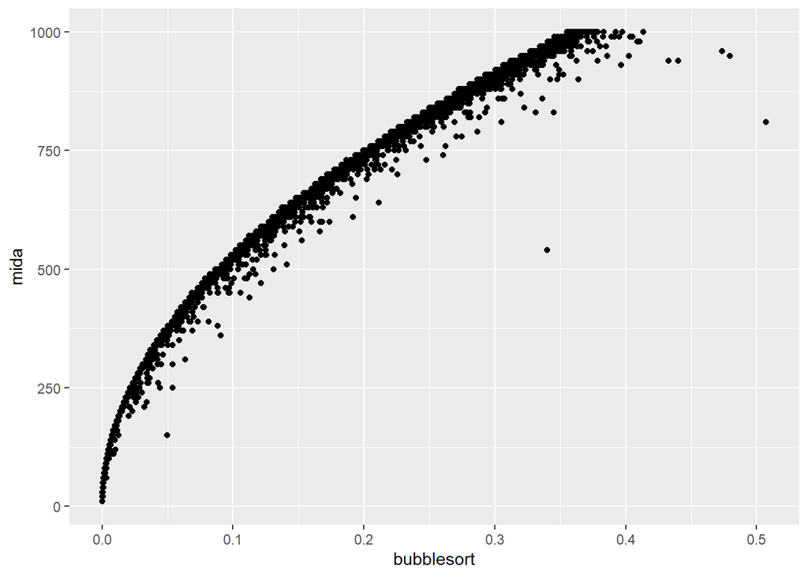

```r
ggplot(data = simulacions) +
  geom_point(aes(y = mida, x = bubblesort))
```

### QuickSort *desordenat*

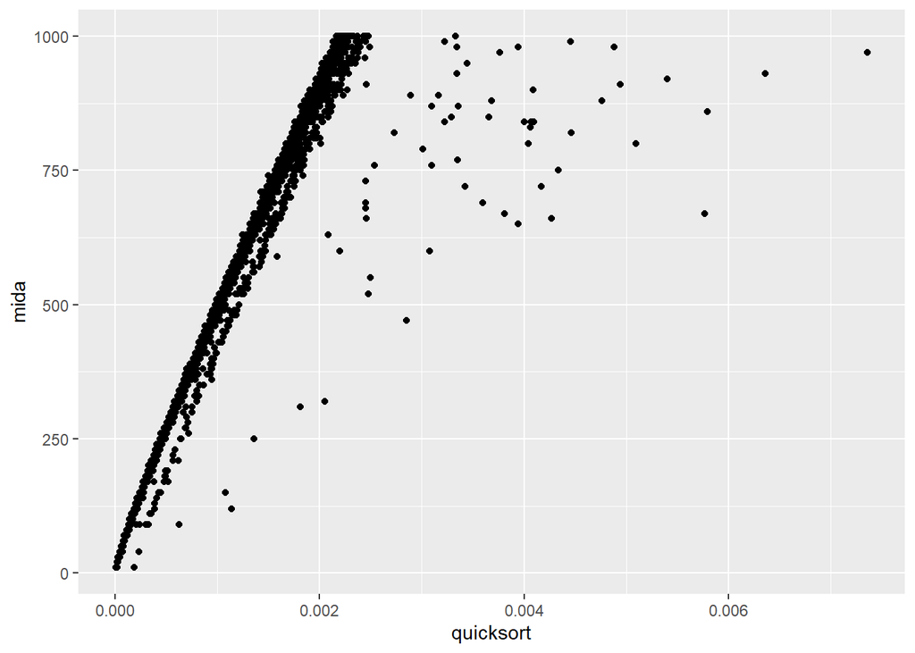

```r
ggplot(data = simulacions) +
  geom_point(aes(y = mida, x = quicksort))
```

### MergeSort *desordenat*

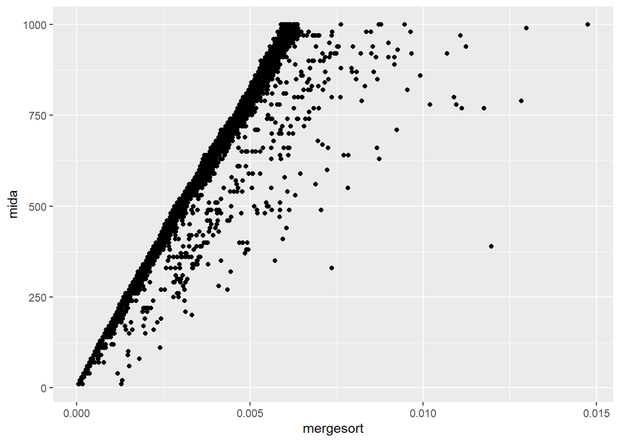

```r
ggplot(data = simulacions) +
  geom_point(aes(y = mida, x = mergesort))
```

### BubbleSort *ordenat*

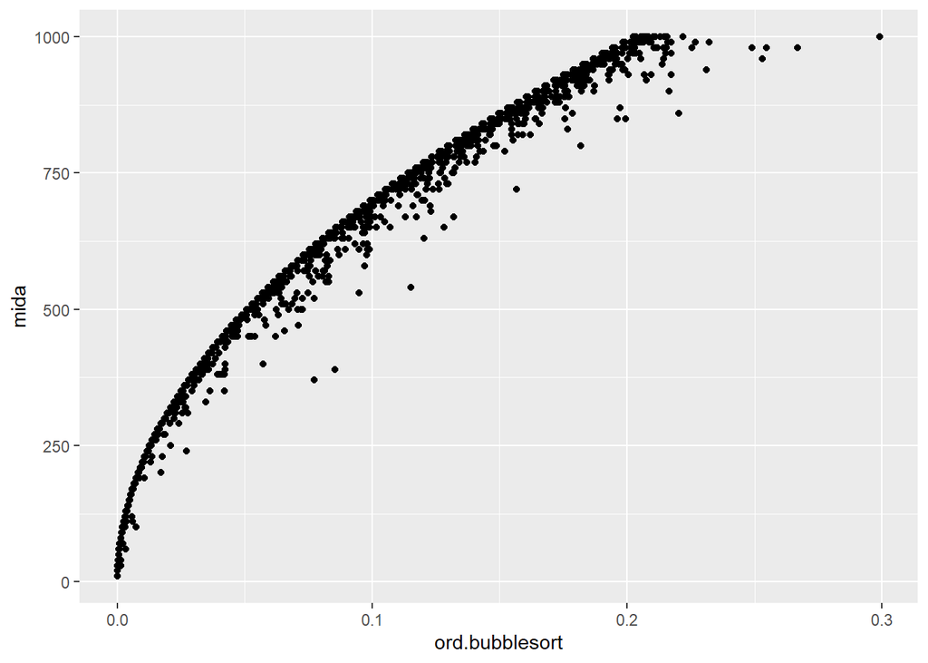

```r
ggplot(data = simulacions) +
  geom_point(aes(y = mida, x = ord.bubblesort))
```

### QuickSort *ordenat*

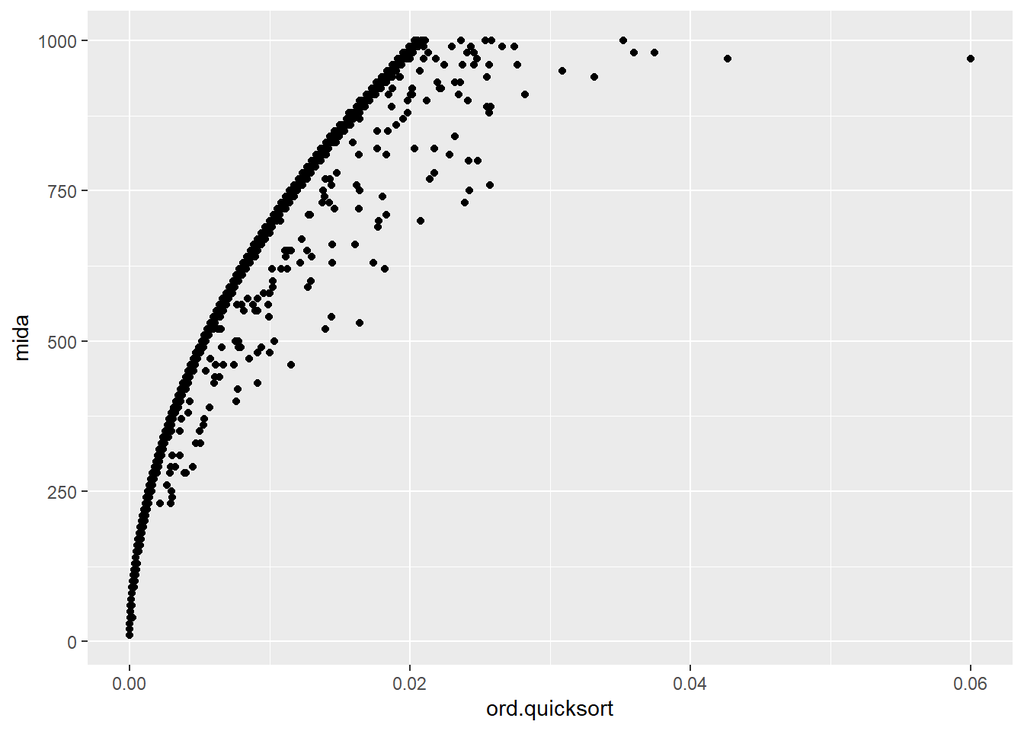

```r
ggplot(data = simulacions) +
  geom_point(aes(y = mida, x = ord.quicksort))
```

### MergeSort *ordenat*

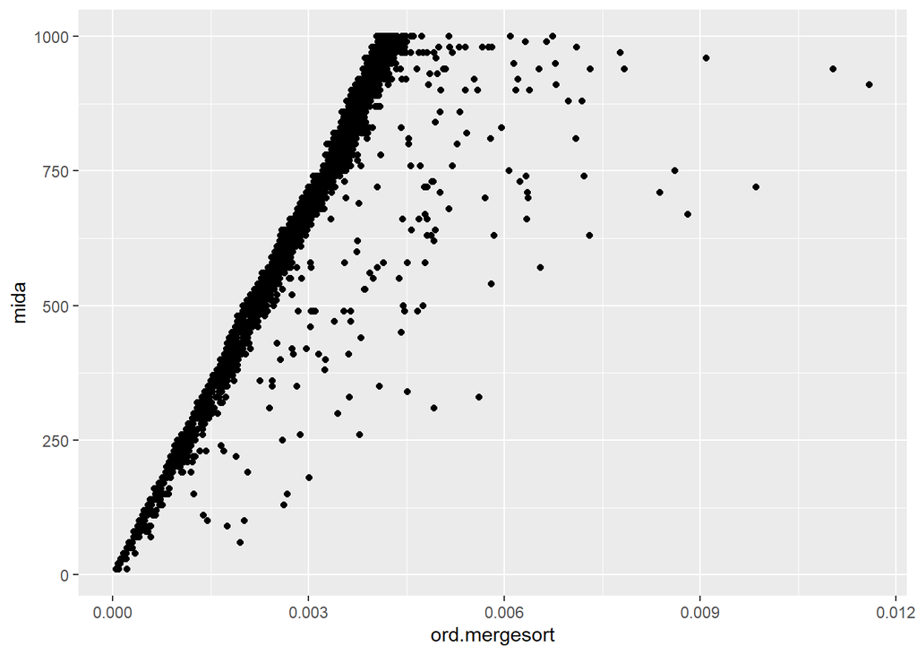

```r
ggplot(data = simulacions) +
  geom_point(aes(y = mida, x = ord.mergesort))
```

Visualitzant les gràfiques, és quan ens vam preguntar quina és la forma dels errors i com podem modelar la v.a. `temps d'execució` de cada algoritme, si el resultat variava molt quan el vector ja estava ordenat.

## Resultats sobre la qüestió principal

Per respondre a la qüestió principal vam ajustar alguns models, que calculant el seu $R^2$, vam comprovar que explicaven bastant bé els errors.

Aquests models eren els següents:

```r
mods
```

```
## $lm.bubblesort
##
## Call:
## lm(formula = bubblesort ~ mida + I(mida^2), data = simulacions)
##
## Coefficients:
## (Intercept)         mida    I(mida^2)
##   7.084e-05   -1.798e-06    3.716e-07
##
##
## $lm.quicksort
##
## Call:
## lm(formula = quicksort ~ mida + I(mida * log(mida)), data = simulacions)
##
## Coefficients:
##         (Intercept)                 mida  I(mida * log(mida))
##           1.773e-05           -2.843e-07            3.771e-07
##
##
## $lm.mergesort
##
## Call:
## lm(formula = mergesort ~ mida + I(mida * log(mida)), data = simulacions)
##
## Coefficients:
##         (Intercept)                 mida  I(mida * log(mida))
##          -1.784e-05            5.344e-06            1.656e-07
```

```r
mods.ord
```

```
## $lm.bubblesort
##
## Call:
## lm(formula = ord.bubblesort ~ mida + I(mida^2), data = simulacions)
##
## Coefficients:
## (Intercept)         mida    I(mida^2)
##  -7.273e-06    1.077e-06    2.070e-07
##
##
## $lm.quicksort
##
## Call:
## lm(formula = ord.quicksort ~ mida + I(mida^2), data = simulacions)
##
## Coefficients:
## (Intercept)         mida    I(mida^2)
##   1.478e-05    3.437e-07    2.090e-08
##
##
## $lm.mergesort
##
## Call:
## lm(formula = ord.mergesort ~ mida + I(mida * log(mida)), data = simulacions)
##
## Coefficients:
##         (Intercept)                 mida  I(mida * log(mida))
##           1.450e-05            4.497e-06           -1.057e-08
```

I el seu $R^2$ era el següent:

```r
tibble(
  bubblesort = 1 - (SQR$bubblesort/SQT$bubblesort),
  quicksort = 1 - (SQR$quicksort/SQT$quicksort),
  mergesort = 1 - (SQR$mergesort/SQT$mergesort)
)
```

```
## # A tibble: 1 × 3
##   bubblesort quicksort mergesort
##        <dbl>     <dbl>     <dbl>
## 1      0.993     0.898     0.916
```

```r
tibble(
  bubblesort.ord = 1 - (SQR.ord$bubblesort/SQT.ord$bubblesort),
  quicksort.ord = 1 - (SQR.ord$quicksort/SQT.ord$quicksort),
  mergesort.ord = 1 - (SQR.ord$mergesort/SQT.ord$mergesort)
)
```

```
## # A tibble: 1 × 3
##   bubblesort.ord quicksort.ord mergesort.ord
##            <dbl>         <dbl>         <dbl>
## 1          0.994         0.966         0.902
```

I podem veure que són bons models, i que podem fer servir per estudiar la forma dels errors, *qüestió principal*.

Els errors tenien la forma següent:

#### BubbleSort *desordenat*

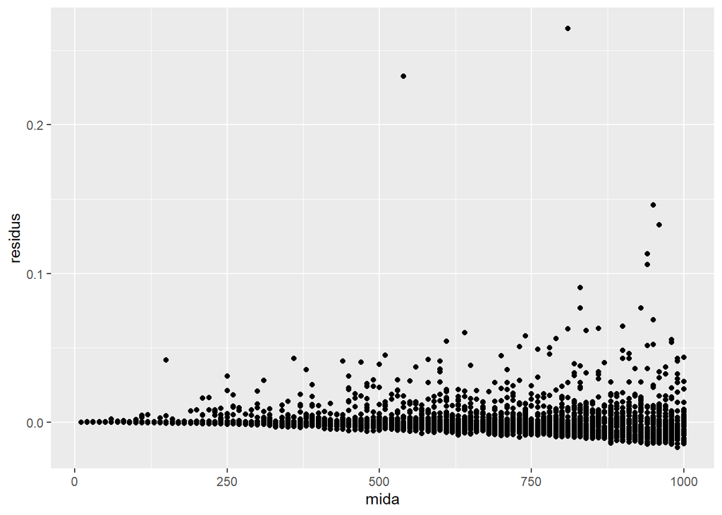

```r
ggplot(data = mutate(simulacions, residus = residuals(mods$lm.bubblesort))) +
  geom_point(aes(x = mida, y = residus))
```

#### QuickSort *desordenat*

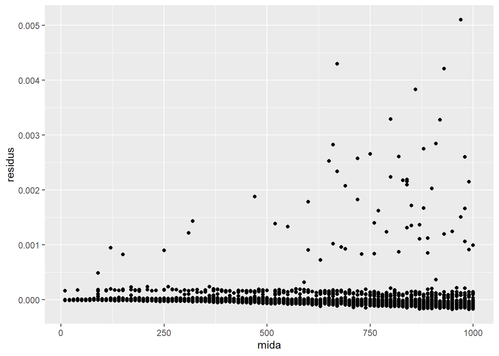

```r
ggplot(data = mutate(simulacions, residus = residuals(mods$lm.quicksort))) +
  geom_point(aes(x = mida, y = residus))
```

#### MergeSort *desordenat*

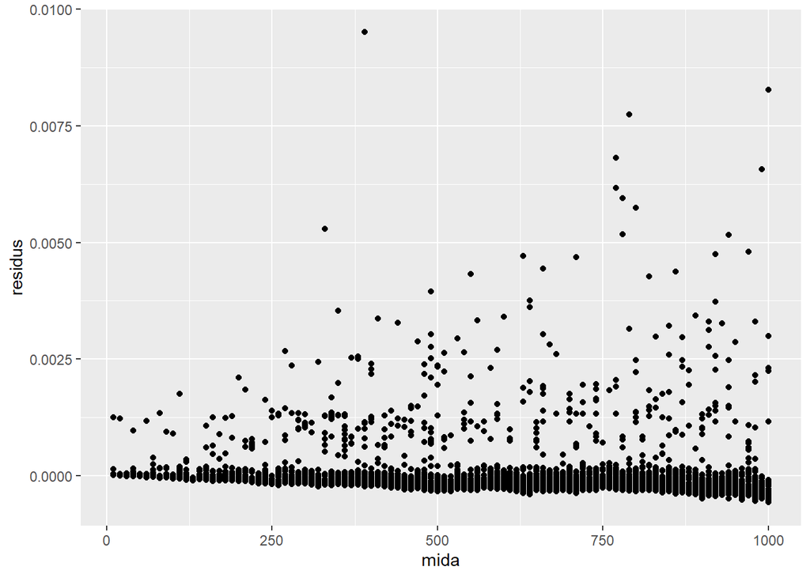

```r
ggplot(data = mutate(simulacions, residus = residuals(mods$lm.mergesort))) +
  geom_point(aes(x = mida, y = residus))
```

#### BubbleSort *ordenat*

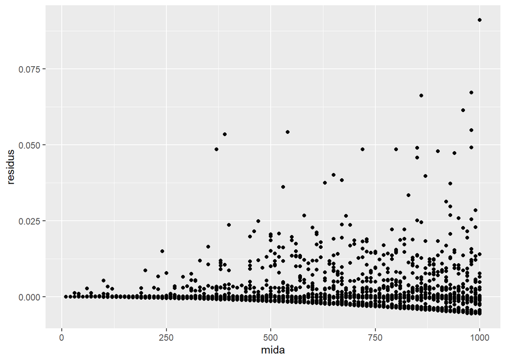

```r
ggplot(data = mutate(simulacions, residus = residuals(mods.ord$lm.bubblesort))) +
  geom_point(aes(x = mida, y = residus))
```

#### QuickSort *ordenat*

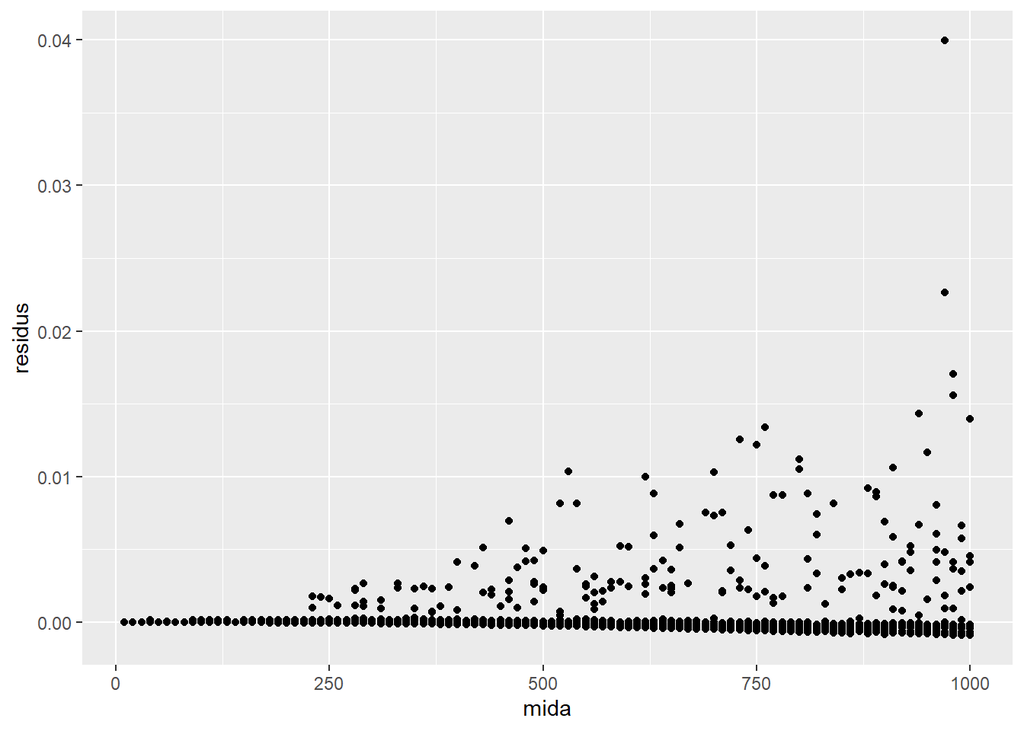

```r
ggplot(data = mutate(simulacions, residus = residuals(mods.ord$lm.quicksort))) +
  geom_point(aes(x = mida, y = residus))
```

#### MergeSort *ordenat*

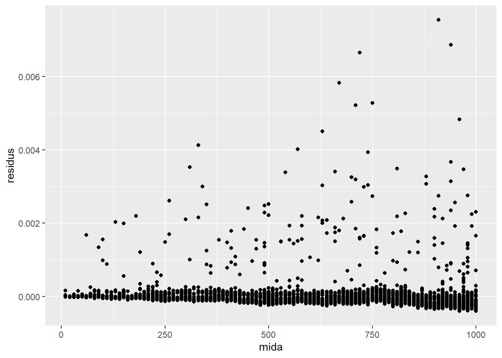

```r
ggplot(data = mutate(simulacions, residus = residuals(mods.ord$lm.mergesort))) +
  geom_point(aes(x = mida, y = residus))
```

També podíem visualitzar-los amb un histograma.

#### BubbleSort *desordenat*

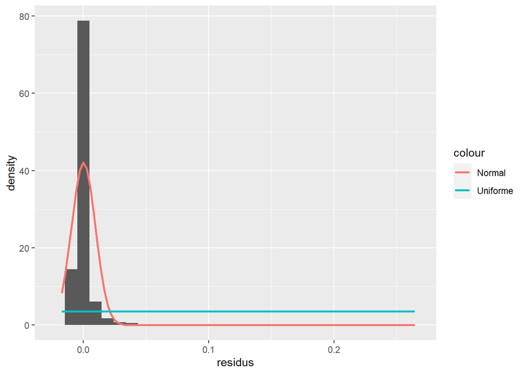

```r
histograma(mods$lm.bubblesort)
```

#### QuickSort *desordenat*

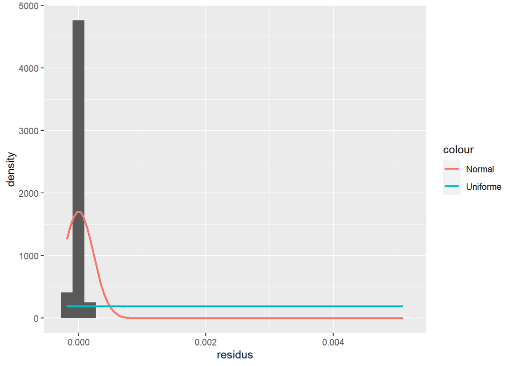

```r
histograma(mods$lm.quicksort)
```

#### MergeSort *desordenat*

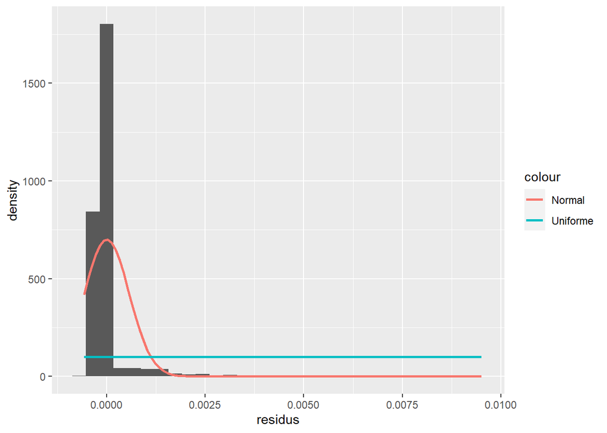

```r
histograma(mods$lm.mergesort)
```

#### BubbleSort *ordenat*

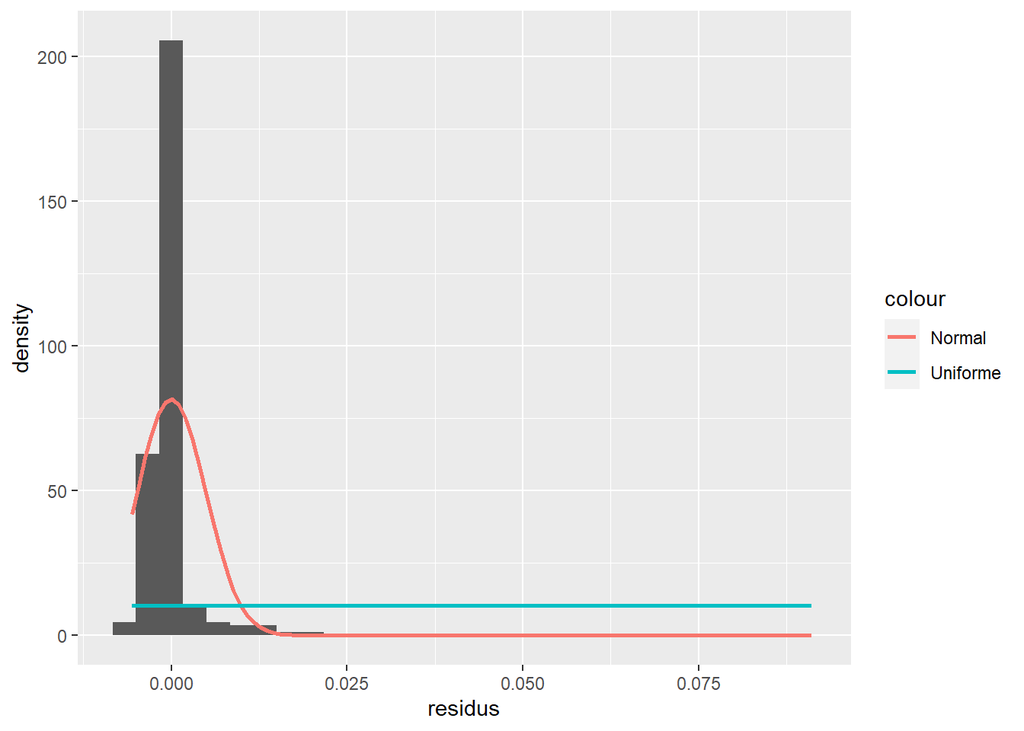

```r
histograma(mods.ord$lm.bubblesort)
```

#### QuickSort *ordenat*

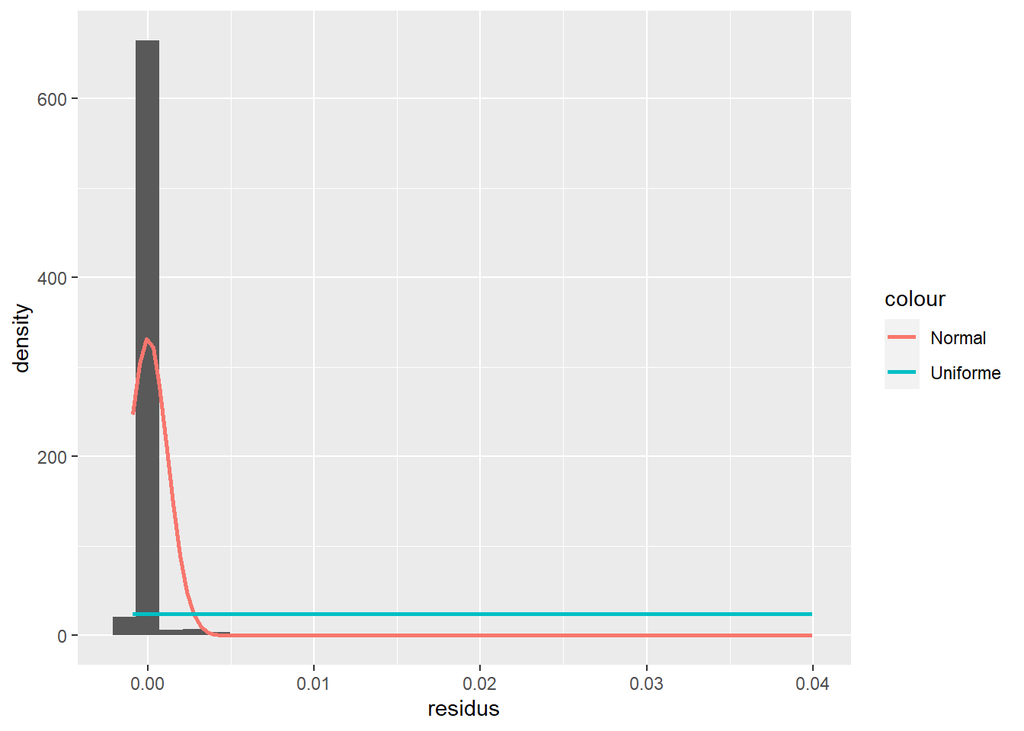

```r
histograma(mods.ord$lm.quicksort)
```

#### MergeSort *ordenat*

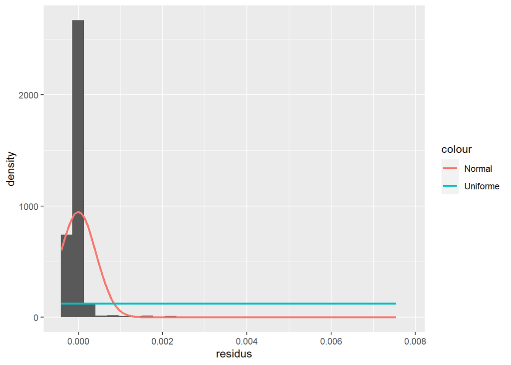

```r
histograma(mods.ord$lm.mergesort)
```

I observant els gràfics, podem tenir alguna sospita sobre quina és la forma dels errors.

## Qüestions secundàries

Les qüestions secundaries han estat les següents:

1. La mida del vector és independent del temps d’execució de cada algoritme?
2. Els algoritmes segueixen l’ordre que haurien de seguir *segons la teoria*, p.ex. bubblesort és $O(n^2)$, i quicksort i mergesort són $O(n \cdot log(n))$?
3. Quin algorisme és més estable? És a dir, tenen la mateixa eficiència per vectors desordenats com per vectors ordenats?

## Resultats i Sospites sobre les qüestions secundàries

Sobre la qüestió **3**, també podem veure si es estable o no veient els gràfics, p.e. si el temps d’un algoritme té la mateixa forma *p.e. $O(n^2)$* tant amb vectors ordenats com amb desordenats, llavors podem dir que l’algoritme és estable. Altrament, no és estable.